# Trabajo1

2025-10-15

EJERCICIO 1

El supermercado EcoMarket quiere elegir una estrategia de fidelización de clientes. Se estudian cuatro alternativas: B1: Tarjeta de puntos B2: Descuentos por app B3: Suscripción mensual B4: Campañas ecológicas

Los resultados (beneficio neto anual, miles de €) dependen del grado de digitalización de los clientes (F1 a F4).

```
    F1   F2   F3   F4
```

B1: 100 80 60 40 B2: 120 90 50 30 B3: 130 100 70 20 B4: 90 70 60 50

```r
X2 <- crea.tablaX(
  c(100,80,60,40,
    120,90,50,30,
    130,100,70,20,
    90,70,60,50),
  numalternativas = 4, numestados = 4,
  nb_alternativas = c("B1_Tarjeta","B2_DescuentosApp","B3_Suscripcion","B4_CampañasEco"),
  nb_estados = c("F1","F2","F3","F4")
)
X2
```

```
##                   F1  F2 F3 F4
## B1_Tarjeta       100  80 60 40
## B2_DescuentosApp 120  90 50 30
## B3_Suscripcion   130 100 70 20
## B4_CampañasEco    90  70 60 50
```

```r
criterio.Wald(X2, favorable=TRUE)
```

```
## $criterio
## [1] "Wald"
##
## $metodo
## [1] "favorable"
##
## $tablaX
##                   F1  F2 F3 F4
## B1_Tarjeta       100  80 60 40
## B2_DescuentosApp 120  90 50 30
## B3_Suscripcion   130 100 70 20
## B4_CampañasEco    90  70 60 50
##
## $ValorAlternativas
##       B1_Tarjeta B2_DescuentosApp   B3_Suscripcion   B4_CampañasEco
##               40               30               20               50
##
## $ValorOptimo
## [1] 50
##
## $AlternativaOptima
## B4_CampañasEco
##              4
```

Segun el criterio de Wald, la mejor alternativa es la 4, que es la de Campañas ECO

```r
criterio.Optimista(X2, favorable=T)
```

```
## $criterio
## [1] "Optimista"
##
## $metodo
## [1] "favorable"
##
## $tablaX
##                   F1  F2 F3 F4
## B1_Tarjeta       100  80 60 40
## B2_DescuentosApp 120  90 50 30
## B3_Suscripcion   130 100 70 20
## B4_CampañasEco    90  70 60 50
##
## $ValorAlternativas
##       B1_Tarjeta B2_DescuentosApp   B3_Suscripcion   B4_CampañasEco
##              100              120              130               90
##
## $ValorOptimo
## [1] 130
##
## $AlternativaOptima
## B3_Suscripcion
##              3
```

Según el criterio Optimista, la mejor alternativa es la 3, que es suscripción.

```r
criterio.Hurwicz(X2, alfa= 0.5, favorable=T)
```

```
## $criterio
## [1] "Hurwicz"
##
## $alfa
## [1] 0.5
##
## $metodo
## [1] "favorable"
##
## $tablaX
##                   F1  F2 F3 F4
## B1_Tarjeta       100  80 60 40
## B2_DescuentosApp 120  90 50 30
## B3_Suscripcion   130 100 70 20
## B4_CampañasEco    90  70 60 50
##
## $ValorAlternativas
##       B1_Tarjeta B2_DescuentosApp   B3_Suscripcion   B4_CampañasEco
##               70               75               75               70
##
## $ValorOptimo
## [1] 75
##
## $AlternativaOptima
## B2_DescuentosApp   B3_Suscripcion
##                2                3
```

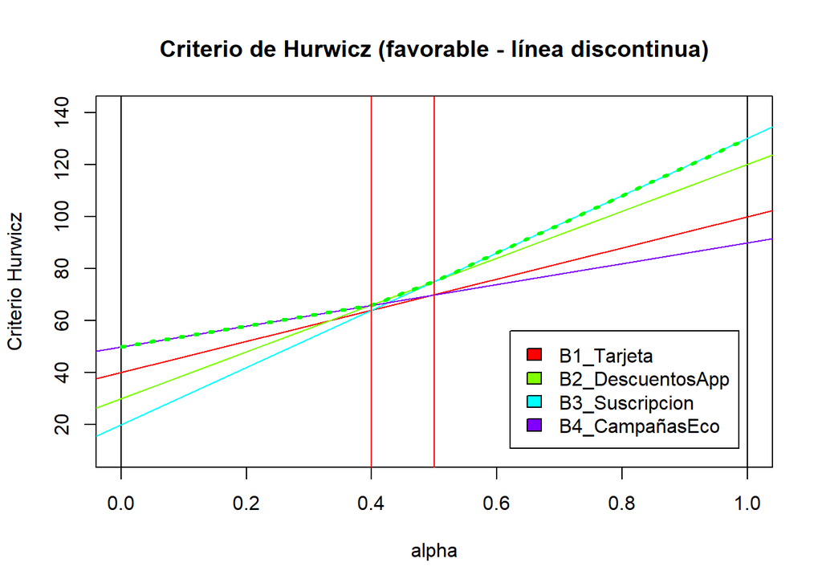

```
## $AltOptimas
## [1] 4 2 3
##
## $PuntosDeCorte
## [1] 0.4 0.5
##
## $IntervalosAlfa
##            Intervalo       Alternativa
## Soluciones "( 0 , 0.4 )"   "4"
##            "( 0.4 , 0.5 )" "2"
##            "( 0.5 , 1 )"   "3"
```

```r
dibuja.criterio.Hurwicz_Intervalos(X2, favorable=T, T)
```

Para alfa con valor entre ( 0 , 0.4 ) , la mejor Alternativa es la 4. Para alfa con valor entre ( 0.4 , 0.5 ) , la mejor Alternativa es la 2. Para alfa con valor entre ( 0.5 , 1 ) , la mejor Alternativa es la 3.

```r
criterio.Savage(X2, favorable=T)
```

```
## $criterio
## [1] "Savage"
##
## $metodo
## [1] "favorable"
##
## $tablaX
##                   F1  F2 F3 F4
## B1_Tarjeta       100  80 60 40
## B2_DescuentosApp 120  90 50 30
## B3_Suscripcion   130 100 70 20
## B4_CampañasEco    90  70 60 50
##
## $Mejores
##  F1  F2  F3  F4
## 130 100  70  50
##
## $Pesos
##                  F1 F2 F3 F4
## B1_Tarjeta       30 20 10 10
## B2_DescuentosApp 10 10 20 20
## B3_Suscripcion    0  0  0 30
## B4_CampañasEco   40 30 10  0
##
## $ValorAlternativas
##       B1_Tarjeta B2_DescuentosApp   B3_Suscripcion   B4_CampañasEco
##               30               20               30               40
##
## $ValorOptimo
## [1] 20
##
## $AlternativaOptima
## B2_DescuentosApp
##                2
```

Segun el criterio de Savage, la mejor alternativa es la 2.

```r
criterio.PuntoIdeal(X2, favorable=T)
```

```
## $criterio
## [1] "Punto Ideal"
##
## $metodo
## [1] "favorable"
##
## $tablaX
##                   F1  F2 F3 F4
## B1_Tarjeta       100  80 60 40
## B2_DescuentosApp 120  90 50 30
## B3_Suscripcion   130 100 70 20
## B4_CampañasEco    90  70 60 50
##
## $Mejores
##  F1  F2  F3  F4
## 130 100  70  50
##
## $ValorAlternativas
##       B1_Tarjeta B2_DescuentosApp   B3_Suscripcion   B4_CampañasEco
##         38.72983         31.62278         30.00000         50.99020
##
## $ValorOptimo
## [1] 30
##
## $AlternativaOptima
## B3_Suscripcion
##              3
```

Segun el criterio de PuntoIdeal , la mejor alternativa es la 3.

```r
criterio.Laplace(X2, favorable=T)
```

```
## $criterio
## [1] "Laplace"
##
## $metodo
## [1] "favorable"
##
## $tablaX
##                   F1  F2 F3 F4
## B1_Tarjeta       100  80 60 40
## B2_DescuentosApp 120  90 50 30
## B3_Suscripcion   130 100 70 20
## B4_CampañasEco    90  70 60 50
##
## $ValorAlternativas
##       B1_Tarjeta B2_DescuentosApp   B3_Suscripcion   B4_CampañasEco
##             70.0             72.5             80.0             67.5
##
## $ValorOptimo
## [1] 80
##
## $AlternativaOptima
## B3_Suscripcion
##              3
```

Segun el criterio de LaPlace, la mejor alternativa es la 3.

```r
criterio.Wald(X2, favorable = F)
```

```
## $criterio
## [1] "Wald"
##
## $metodo
## [1] "desfavorable"
##
## $tablaX
##                   F1  F2 F3 F4
## B1_Tarjeta       100  80 60 40
## B2_DescuentosApp 120  90 50 30
## B3_Suscripcion   130 100 70 20
## B4_CampañasEco    90  70 60 50
##
## $ValorAlternativas
##       B1_Tarjeta B2_DescuentosApp   B3_Suscripcion   B4_CampañasEco
##              100              120              130               90
##
## $ValorOptimo
## [1] 90
##
## $AlternativaOptima
## B4_CampañasEco
##              4
```

Segun el criterio de Wald, la mejor alternativa es 4.

EJERCICIO 2 El supermercado EcoMarket quiere decidir cómo invertir en la mejora de su área de productos frescos.

Alternativas: B1: Ampliar la sección de frutas y verduras B2: Crear una zona de productos locales B3: Implementar refrigeración más eficiente B4: Introducir comidas preparadas frescas

Los beneficios esperados (en miles de euros) dependen de la reacción del mercado (F1 a F4): F1: Alta demanda de productos naturales F2: Demanda estable F3: Competencia más fuerte F4: Descenso del consumo

```
    F1   F2   F3   F4
```

B1: 120 90 60 40 B2: 130 100 70 50 B3: 140 110 80 60 B4: 100 85 65 55

```r
X <- crea.tablaX(
  c(120,90,60,40,
    130,100,70,50,
    140,110,80,60,
    100,85,65,55),
  numalternativas = 4, numestados = 4,
  nb_alternativas = c("B1_FrutasVerduras","B2_ProductosLocales","B3_Refrigeracion","B4_ComidasFrescas"),
  nb_estados = c("F1","F2","F3","F4")
)

criterio.Todos(X, alfa=0.4, favorable=TRUE)
```

```
##                      F1  F2 F3 F4             Wald        Optimista
## B1_FrutasVerduras   120  90 60 40               40              120
## B2_ProductosLocales 130 100 70 50               50              130
## B3_Refrigeracion    140 110 80 60               60              140
## B4_ComidasFrescas   100  85 65 55               55              100
## iAlt.Opt (fav.)      --  -- -- -- B3_Refrigeracion B3_Refrigeracion
##                              Hurwicz           Savage          Laplace
## B1_FrutasVerduras                 72               20            77.50
## B2_ProductosLocales               82               10            87.50
## B3_Refrigeracion                  92                0            97.50
## B4_ComidasFrescas                 73               40            76.25
## iAlt.Opt (fav.)     B3_Refrigeracion B3_Refrigeracion B3_Refrigeracion
##                          Punto Ideal     Veces Optima
## B1_FrutasVerduras              40.00                0
## B2_ProductosLocales            20.00                0
## B3_Refrigeracion                0.00                6
## B4_ComidasFrescas              49.75                0
## iAlt.Opt (fav.)     B3_Refrigeracion B3_Refrigeracion
```

Vemos que la alternativa 3 es la Óptima en todos los criterios, es decir la Refrigeracón.